# Practical Machine Learning Course Project

Hao Liu

September 10, 2016

## Background

Using devices such as Jawbone Up, Nike FuelBand, and Fitbit it is now possible to collect a large amount of data about personal activity relatively inexpensively. These type of devices are part of the quantified self movement - a group of enthusiasts who take measurements about themselves regularly to improve their health, to find patterns in their behavior, or because they are tech geeks. One thing that people regularly do is quantify how much of a particular activity they do, but they rarely quantify how well they do it. In this project, your goal will be to use data from accelerometers on the belt, forearm, arm, and dumbell of 6 participants. They were asked to perform barbell lifts correctly and incorrectly in 5 different ways. More information is available from the website here: http://groupware.les.inf.puc-rio.br/har (see the section on the Weight Lifting Exercise Dataset).

Six young health participants were asked to perform one set of 10 repetitions of the Unilateral Dumbbell Biceps Curl in five different fashions: exactly according to the specification (Class A), throwing the elbows to the front (Class B), lifting the dumbbell only halfway (Class C), lowering the dumbbell only halfway (Class D) and throwing the hips to the front (Class E).

Class A corresponds to the specified execution of the exercise, while the other 4 classes correspond to common mistakes. Participants were supervised by an experienced weight lifter to make sure the execution complied to the manner they were supposed to simulate. The exercises were performed by six male participants aged between 20-28 years, with little weight lifting experience. We made sure that all participants could easily simulate the mistakes in a safe and controlled manner by using a relatively light dumbbell (1.25kg).

## Project Requirements

The goal of your project is to predict the manner in which they did the exercise. This is the “classe” variable in the training set. You may use any of the other variables to predict with. You should create a report describing how you built your model, how you used cross validation, what you think the expected out of sample error is, and why you made the choices you did. You will also use your prediction model to predict 20 different test cases.

```r
suppressMessages(library(curl))
suppressMessages(library(caret))
suppressMessages(library(rpart))
suppressMessages(library(rattle))
suppressMessages(library(randomForest))

filename_1 <- "trainData.csv"
fileUrl <- "https://d396qusza40orc.cloudfront.net/predmachlearn/pml-training.csv"
download.file(fileUrl, destfile = filename_1)

df_0<-read.csv(filename_1,na.strings=c("NA","#DIV/0!",""))
dim(df_0)
```

```
## [1] 19622   160
```

The dataset has too many variables. Upon data exploration, I observed some variables have large number of NAs that would impact the training of model. The following step removed variables that are:

1. Variables that only have NAs, and therefore have a zero value from nearZeroVar()
2. The first several columns that has subject’s names and the data/time. This is not a time series forecast, so these information is not relevant to the modeling.

```r
nsv<-nearZeroVar(df_0)
df_1<-df_0[,-nsv]#remove statistically not significant variables
df_1<-df_1[,-c(1:5)] #remove first several columns that are not relevant for the prediction
```

The second step of the data scrubbing is to review the distribution of NA values in the variables. The analysis below showed the distribution is very polarized. A large number of variables have over 95% of NA in their records. Such variables would cause the model training to fail, and need to be removed.

After removing these variables, the number of variables is reduced from 160 in the source data to 54. This makes the modeling more efficient and trainable.

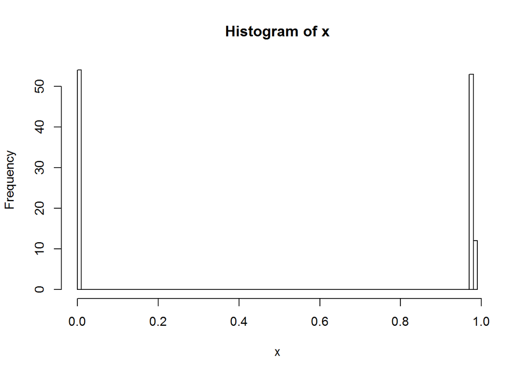

```r
#identify relevant covariates
x<-apply(df_1,2,function(x) sum(is.na(x)))/nrow(df_1) #calculate the percentage of NA for each variable
hist(x, breaks=100)
```

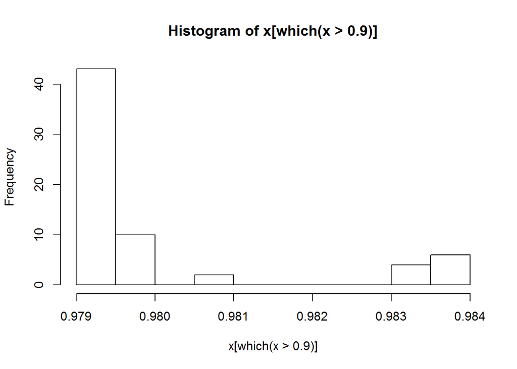

```r
hist(x[which(x>0.9)]) #large number of variables have over 95% of NA
```

```r
df_2<-df_1[,which(x<0.9)]
```

Setting up training and testing dataset

```r
#set up training and testing dataset
inTrain<-createDataPartition(df_2$classe,p=0.7,list=F)
training<-df_2[inTrain,]
testing<-df_2[-inTrain,]
```

Based on the problem to model the class of the activities, this is a classification problem, and therefore the two primarily modeling method: decision tree (rpart package) and random forest (randomForest package) should be considered.

[figure not shown]

```r
#using classification tree model
modFit_rpart<-rpart(classe~.,method="class",data=training)
fancyRpartPlot(modFit_rpart)
```

```r
pred_rpart<-predict(modFit_rpart,newdata=testing,type="class")
confusionMatrix(pred_rpart,testing$classe)
```

```
## Confusion Matrix and Statistics
##
##           Reference
## Prediction    A    B    C    D    E
##          A 1520  261   34  108   79
##          B   34  639   74   30  108
##          C   16   60  841  140   81
##          D   94  142   49  639  130
##          E   10   37   28   47  684
##
## Overall Statistics
##
##                Accuracy : 0.7346
##                  95% CI : (0.7231, 0.7458)
##     No Information Rate : 0.2845
##     P-Value [Acc > NIR] : < 2.2e-16
##
##                   Kappa : 0.6623
##  Mcnemar's Test P-Value : < 2.2e-16
##
## Statistics by Class:
##
##                      Class: A Class: B Class: C Class: D Class: E
## Sensitivity            0.9080   0.5610   0.8197   0.6629   0.6322
## Specificity            0.8855   0.9482   0.9389   0.9157   0.9746
## Pos Pred Value         0.7592   0.7220   0.7390   0.6063   0.8486
## Neg Pred Value         0.9603   0.9000   0.9610   0.9327   0.9216
## Prevalence             0.2845   0.1935   0.1743   0.1638   0.1839
## Detection Rate         0.2583   0.1086   0.1429   0.1086   0.1162
## Detection Prevalence   0.3402   0.1504   0.1934   0.1791   0.1370
## Balanced Accuracy      0.8968   0.7546   0.8793   0.7893   0.8034
```

```r
modFit_rpart
```

```
## n= 13737
##
## node), split, n, loss, yval, (yprob)
##       * denotes terminal node
##
##    1) root 13737 9831 A (0.28 0.19 0.17 0.16 0.18)
##      2) roll_belt< 130.5 12591 8696 A (0.31 0.21 0.19 0.18 0.11)
##        4) pitch_forearm< -34 1047    8 A (0.99 0.0076 0 0 0) *
##        5) pitch_forearm>=-34 11544 8688 A (0.25 0.23 0.21 0.2 0.12)
##         10) magnet_dumbbell_y< 438.5 9779 6984 A (0.29 0.18 0.24 0.19 0.11)
##           20) roll_forearm< 123.5 6061 3560 A (0.41 0.18 0.18 0.17 0.06)
##             40) magnet_dumbbell_z< -27.5 2068  662 A (0.68 0.2 0.014 0.074 0.033) *
##             41) magnet_dumbbell_z>=-27.5 3993 2898 A (0.27 0.16 0.27 0.21 0.074)
##               82) num_window< 241.5 918  141 A (0.85 0.0011 0 0.062 0.09) *
##               83) num_window>=241.5 3075 1983 C (0.1 0.21 0.36 0.26 0.069)
##                166) accel_dumbbell_y>=-40.5 2620 1835 D (0.12 0.24 0.26 0.3 0.081)
##                  332) roll_belt>=125.5 609  247 C (0 0.36 0.59 0.041 0.0049)
##                    664) pitch_belt< -42.65 232   21 B (0 0.91 0 0.078 0.013) *
##                    665) pitch_belt>=-42.65 377   15 C (0 0.021 0.96 0.019 0) *
##                  333) roll_belt< 125.5 2011 1251 D (0.16 0.21 0.15 0.38 0.1)
##                    666) num_window< 278.5 230  108 C (0 0.47 0.53 0 0)
##                     1332) num_window< 260 108    0 B (0 1 0 0 0) *
##                     1333) num_window>=260 122    0 C (0 0 1 0 0) *
##                    667) num_window>=278.5 1781 1021 D (0.18 0.17 0.11 0.43 0.12)
##                     1334) pitch_belt< -42.45 384  238 A (0.38 0.34 0.18 0.083 0.01) *
##                     1335) pitch_belt>=-42.45 1397  669 D (0.12 0.13 0.084 0.52 0.15) *
##                167) accel_dumbbell_y< -40.5 455   35 C (0 0.042 0.92 0.035 0) *
##           21) roll_forearm>=123.5 3718 2518 C (0.079 0.18 0.32 0.23 0.19)
##             42) magnet_dumbbell_y< 292.5 2198 1161 C (0.092 0.14 0.47 0.15 0.15)
##               84) magnet_forearm_z< -251.5 169   37 A (0.78 0.071 0 0.047 0.1) *
##               85) magnet_forearm_z>=-251.5 2029  992 C (0.034 0.14 0.51 0.16 0.16)
##                170) num_window< 88.5 253  125 B (0.11 0.51 0 0 0.39) *
##                171) num_window>=88.5 1776  739 C (0.024 0.089 0.58 0.18 0.13) *
##             43) magnet_dumbbell_y>=292.5 1520  998 D (0.061 0.25 0.11 0.34 0.24)
##               86) accel_forearm_x>=-101.5 981  658 E (0.06 0.32 0.15 0.14 0.33)
##                172) magnet_arm_y>=189.5 404  176 B (0.012 0.56 0.22 0.11 0.094) *
##                173) magnet_arm_y< 189.5 577  292 E (0.094 0.14 0.11 0.16 0.49) *
##               87) accel_forearm_x< -101.5 539  157 D (0.061 0.12 0.028 0.71 0.083) *
##         11) magnet_dumbbell_y>=438.5 1765  853 B (0.035 0.52 0.042 0.22 0.18)
##           22) total_accel_dumbbell>=5.5 1270  438 B (0.048 0.66 0.057 0.02 0.22)
##             44) roll_belt>=-0.575 1068  236 B (0.057 0.78 0.068 0.024 0.071) *
##             45) roll_belt< -0.575 202    0 E (0 0 0 0 1) *
##           23) total_accel_dumbbell< 5.5 495  126 D (0 0.16 0.004 0.75 0.089) *
##      3) roll_belt>=130.5 1146   11 E (0.0096 0 0 0 0.99) *
```

Decision trees tend to be unstable with high variance due to overfitting. A slight change in the training data can cause a significant difference in the model. However, they are easy to interpret and can help us to interpret the method behind more complex machine learning such as randomforest that we will train below. As show in the modFit_rpart above, the primary node splits are based on roll_belt and pitch_forearm, which make a lot of common sense for people with gym experience that the angle of the back (belt) and the movement of arm are important to the right pose.

```r
#using rf model
modFit_rf<-randomForest(classe~.,data=training)
pred_rf<-predict(modFit_rf,newdata=testing,method="class")
confusionMatrix(pred_rf,testing$classe)
```

```
## Confusion Matrix and Statistics
##
##           Reference
## Prediction    A    B    C    D    E
##          A 1674    1    0    0    0
##          B    0 1138    1    0    0
##          C    0    0 1025   10    0
##          D    0    0    0  954    1
##          E    0    0    0    0 1081
##
## Overall Statistics
##
##                Accuracy : 0.9978
##                  95% CI : (0.9962, 0.9988)
##     No Information Rate : 0.2845
##     P-Value [Acc > NIR] : < 2.2e-16
##
##                   Kappa : 0.9972
##  Mcnemar's Test P-Value : NA
##
## Statistics by Class:
##
##                      Class: A Class: B Class: C Class: D Class: E
## Sensitivity            1.0000   0.9991   0.9990   0.9896   0.9991
## Specificity            0.9998   0.9998   0.9979   0.9998   1.0000
## Pos Pred Value         0.9994   0.9991   0.9903   0.9990   1.0000
## Neg Pred Value         1.0000   0.9998   0.9998   0.9980   0.9998
## Prevalence             0.2845   0.1935   0.1743   0.1638   0.1839
## Detection Rate         0.2845   0.1934   0.1742   0.1621   0.1837
## Detection Prevalence   0.2846   0.1935   0.1759   0.1623   0.1837
## Balanced Accuracy      0.9999   0.9995   0.9985   0.9947   0.9995
```

Based on the validation of the model, random forest produced much more accurate results that decision tree.

Random forests are a type of ensemble method. An ensemble method is a process in which numerous models are fitted and the results are combined for stronger predictions. While this provides great predictions, inference and explainability are often limited. This is why use Decision Tree in combination with randomforest can achieve great modeling and explainability results.

Predict the final results using the randomforest model and the course project’s test data for final evaluation.

```r
#using classification tree model
filename_test <- "testData.csv"
fileUrl <- "https://d396qusza40orc.cloudfront.net/predmachlearn/pml-testing.csv"
download.file(fileUrl, destfile = filename_test)

df_test<-read.csv(filename_test,na.strings=c("NA","#DIV/0!",""))
pred_rf_test<-predict(modFit_rf,newdata=df_test,method="class")
write.csv(pred_rf_test,"prediction.csv")
```